# Exploratory Data Analysis

In order to not get information from the test set, we will perform the exploratory data analysis only on the train set. The test set will be used only to evaluate the future models. Load the train data set.

```r
data <- read.csv("data/train_raw.csv")
```

```r
str(data)
```

```
## 'data.frame':    5822 obs. of  86 variables:
##  $ MOSTYPE : int  33 37 37 9 40 23 39 33 33 11 ...
##  $ MAANTHUI: int  1 1 1 1 1 1 2 1 1 2 ...
##  $ MGEMOMV : int  3 2 2 3 4 2 3 2 2 3 ...
##  $ MGEMLEEF: int  2 2 2 3 2 1 2 3 4 3 ...
##  $ MOSHOOFD: int  8 8 8 3 10 5 9 8 8 3 ...
##  $ MGODRK  : int  0 1 0 2 1 0 2 0 0 3 ...
##  $ MGODPR  : int  5 4 4 3 4 5 2 7 1 5 ...
##  $ MGODOV  : int  1 1 2 2 1 0 0 0 3 0 ...
##  $ MGODGE  : int  3 4 4 4 4 5 5 2 6 2 ...
##  $ MRELGE  : int  7 6 3 5 7 0 7 7 6 7 ...
##  $ MRELSA  : int  0 2 2 2 1 6 2 2 0 0 ...
##  $ MRELOV  : int  2 2 4 2 2 3 0 0 3 2 ...
##  $ MFALLEEN: int  1 0 4 2 2 3 0 0 3 2 ...
##  $ MFGEKIND: int  2 4 4 3 4 5 3 5 3 2 ...
```

[output cut: 72 more lines]

```r
summary(data)
```

```
##     MOSTYPE         MAANTHUI         MGEMOMV         MGEMLEEF
##  Min.   : 1.00   Min.   : 1.000   Min.   :1.000   Min.   :1.000
##  1st Qu.:10.00   1st Qu.: 1.000   1st Qu.:2.000   1st Qu.:2.000
##  Median :30.00   Median : 1.000   Median :3.000   Median :3.000
##  Mean   :24.25   Mean   : 1.111   Mean   :2.679   Mean   :2.991
##  3rd Qu.:35.00   3rd Qu.: 1.000   3rd Qu.:3.000   3rd Qu.:3.000
##  Max.   :41.00   Max.   :10.000   Max.   :5.000   Max.   :6.000
##     MOSHOOFD          MGODRK           MGODPR          MGODOV
##  Min.   : 1.000   Min.   :0.0000   Min.   :0.000   Min.   :0.00
##  1st Qu.: 3.000   1st Qu.:0.0000   1st Qu.:4.000   1st Qu.:0.00
##  Median : 7.000   Median :0.0000   Median :5.000   Median :1.00
##  Mean   : 5.774   Mean   :0.6965   Mean   :4.627   Mean   :1.07
##  3rd Qu.: 8.000   3rd Qu.:1.0000   3rd Qu.:6.000   3rd Qu.:2.00
##  Max.   :10.000   Max.   :9.0000   Max.   :9.000   Max.   :5.00
##      MGODGE          MRELGE          MRELSA           MRELOV
##  Min.   :0.000   Min.   :0.000   Min.   :0.0000   Min.   :0.00
##  1st Qu.:2.000   1st Qu.:5.000   1st Qu.:0.0000   1st Qu.:1.00
##  Median :3.000   Median :6.000   Median :1.0000   Median :2.00
##  Mean   :3.259   Mean   :6.183   Mean   :0.8835   Mean   :2.29
##  3rd Qu.:4.000   3rd Qu.:7.000   3rd Qu.:1.0000   3rd Qu.:3.00
##  Max.   :9.000   Max.   :9.000   Max.   :7.0000   Max.   :9.00
##     MFALLEEN        MFGEKIND       MFWEKIND      MOPLHOOG        MOPLMIDD
##  Min.   :0.000   Min.   :0.00   Min.   :0.0   Min.   :0.000   Min.   :0.000
##  1st Qu.:0.000   1st Qu.:2.00   1st Qu.:3.0   1st Qu.:0.000   1st Qu.:2.000
##  Median :2.000   Median :3.00   Median :4.0   Median :1.000   Median :3.000
##  Mean   :1.888   Mean   :3.23   Mean   :4.3   Mean   :1.461   Mean   :3.351
##  3rd Qu.:3.000   3rd Qu.:4.00   3rd Qu.:6.0   3rd Qu.:2.000   3rd Qu.:4.000
##  Max.   :9.000   Max.   :9.00   Max.   :9.0   Max.   :9.000   Max.   :9.000
##     MOPLLAAG        MBERHOOG        MBERZELF        MBERBOER
##  Min.   :0.000   Min.   :0.000   Min.   :0.000   Min.   :0.0000
##  1st Qu.:3.000   1st Qu.:0.000   1st Qu.:0.000   1st Qu.:0.0000
##  Median :5.000   Median :2.000   Median :0.000   Median :0.0000
##  Mean   :4.572   Mean   :1.895   Mean   :0.398   Mean   :0.5223
##  3rd Qu.:6.000   3rd Qu.:3.000   3rd Qu.:1.000   3rd Qu.:1.0000
##  Max.   :9.000   Max.   :9.000   Max.   :5.000   Max.   :9.0000
##     MBERMIDD        MBERARBG       MBERARBO          MSKA           MSKB1
##  Min.   :0.000   Min.   :0.00   Min.   :0.000   Min.   :0.000   Min.   :0.000
##  1st Qu.:2.000   1st Qu.:1.00   1st Qu.:1.000   1st Qu.:0.000   1st Qu.:1.000
##  Median :3.000   Median :2.00   Median :2.000   Median :1.000   Median :2.000
##  Mean   :2.899   Mean   :2.22   Mean   :2.306   Mean   :1.621   Mean   :1.607
```

[output cut: 92 more lines]

```
##  Max.   :8.00000   Max.   :1.000000   Max.   :1.000000   Max.   :2.000000
##      ABRAND          AZEILPL             APLEZIER            AFIETS
##  Min.   :0.0000   Min.   :0.0000000   Min.   :0.000000   Min.   :0.00000
##  1st Qu.:0.0000   1st Qu.:0.0000000   1st Qu.:0.000000   1st Qu.:0.00000
##  Median :1.0000   Median :0.0000000   Median :0.000000   Median :0.00000
##  Mean   :0.5701   Mean   :0.0005153   Mean   :0.006012   Mean   :0.03178
##  3rd Qu.:1.0000   3rd Qu.:0.0000000   3rd Qu.:0.000000   3rd Qu.:0.00000
##  Max.   :7.0000   Max.   :1.0000000   Max.   :2.000000   Max.   :3.00000
##     AINBOED            ABYSTAND          CARAVAN
##  Min.   :0.000000   Min.   :0.00000   Min.   :0.00000
##  1st Qu.:0.000000   1st Qu.:0.00000   1st Qu.:0.00000
##  Median :0.000000   Median :0.00000   Median :0.00000
##  Mean   :0.007901   Mean   :0.01426   Mean   :0.05977
##  3rd Qu.:0.000000   3rd Qu.:0.00000   3rd Qu.:0.00000
##  Max.   :2.000000   Max.   :2.00000   Max.   :1.00000
```

According to the data description (https://www.kaggle.com/datasets/uciml/caravan-insurance-challenge) the variables which are truly numeric are “MAANTHUI” and “MGEMOMV”.

All the other variables are numeric but they are actually categorical variables. The variables “MOSTYPE” and “MOSHOOFD” are the only variables that need to be one hot encoded because they represent concepts (religion, social clas, etc.). In particular their encoding is nominal, so it is not possible to consider them as numeric variables.

The other variables are encoded using an encoding that is ordinal, so considering they as numeric seems to be a suitable solution (L1, L3, L4 encodings).

The “CARAVAN” variable (response variable) belongs to the L4 encoding. The L4 encoding domain is 0-9, where 0->0, 1->1-49, 2->50-99, etc. If we check the summary of the “CARAVAN” variable, we can see that the minimum value is 0 and the maximum value is 1. This means that the variable is binary, so we can consider it as a binary variable.

Evaluate the absolute frequency of the response variable.

```r
table(data$CARAVAN)
```

```
##
##    0    1
## 5474  348
```

```r
sum(data$CARAVAN == 1) / nrow(data)
```

```
## [1] 0.05977327
```

Plot of the distribution of the numerical variables “MAANTHUI” and “MGEMOMV”

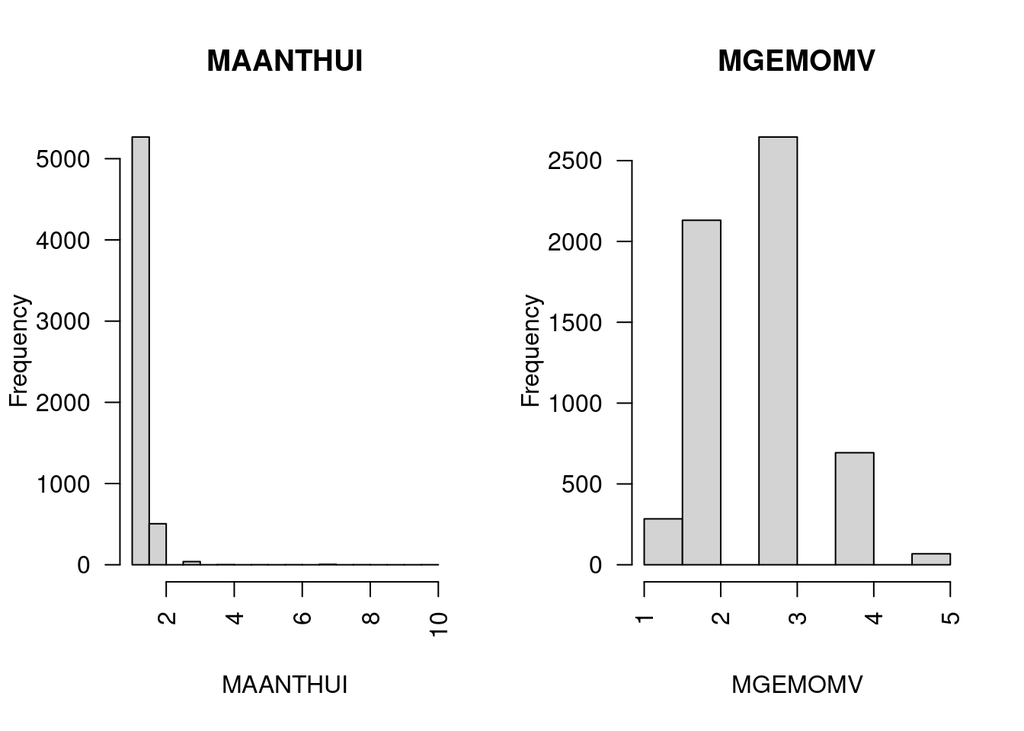

```r
num_vars <- c("MAANTHUI", "MGEMOMV")
par(mfrow = c(1, 2))
for (var in num_vars) {
  hist(data[, var], main = var, xlab = var, las = 2)
}
```

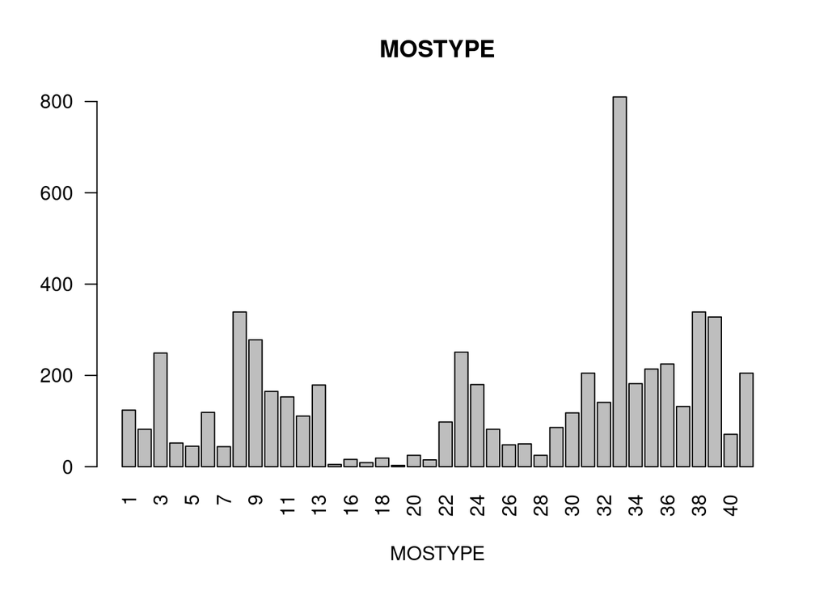

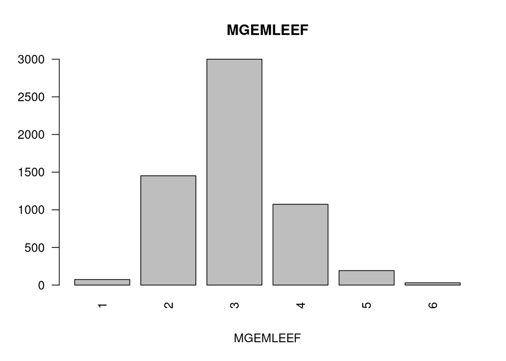

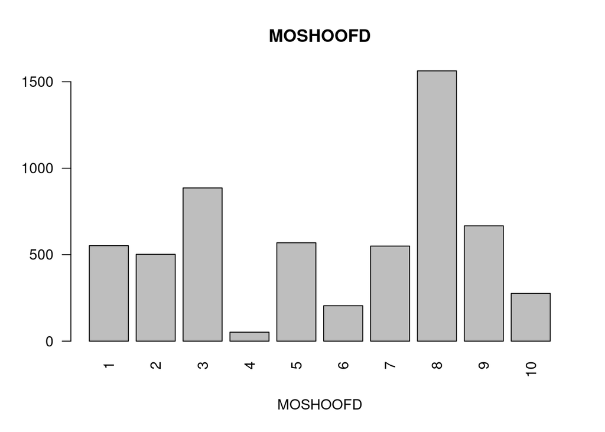

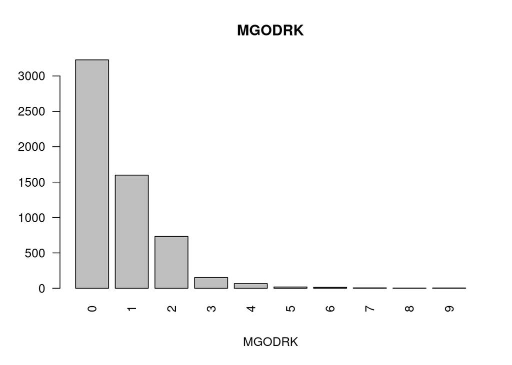

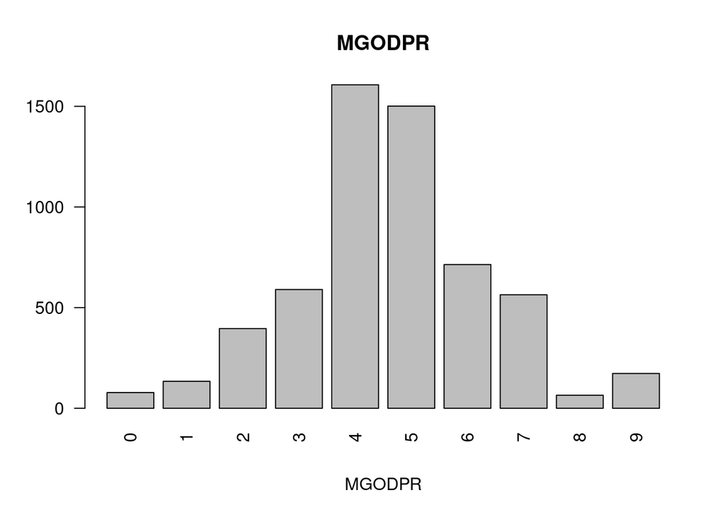

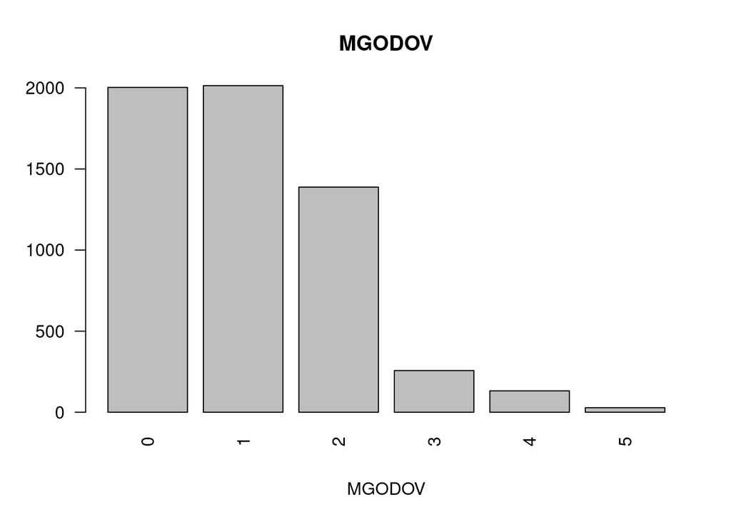

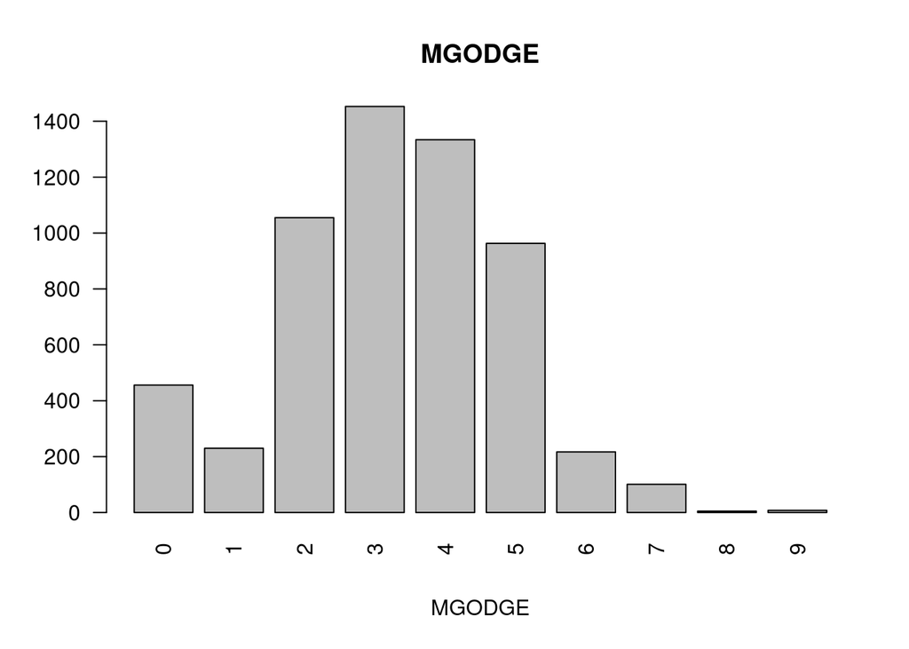

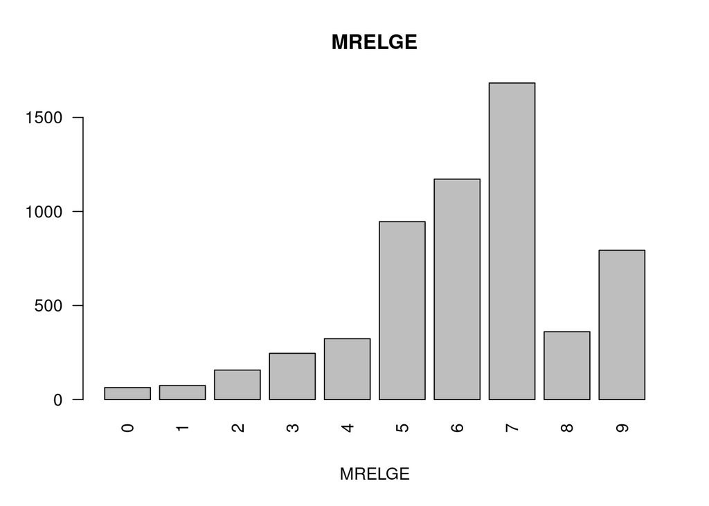

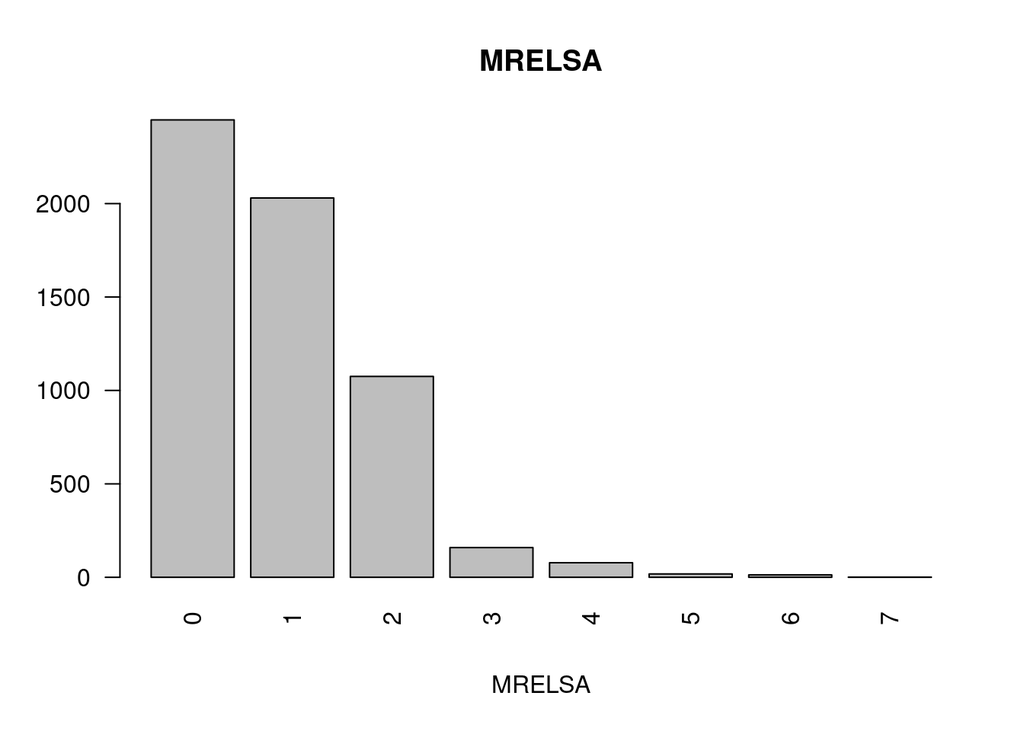

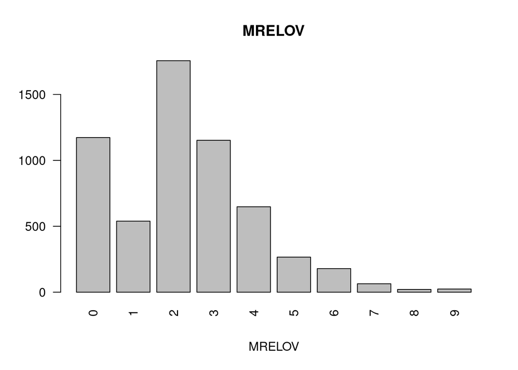

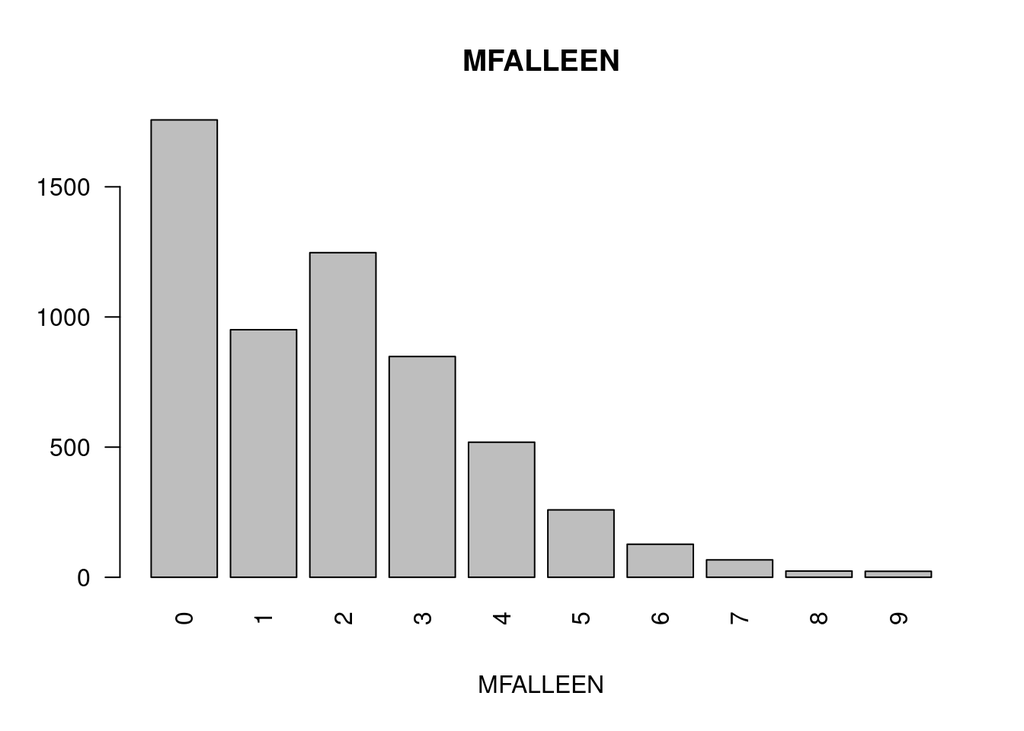

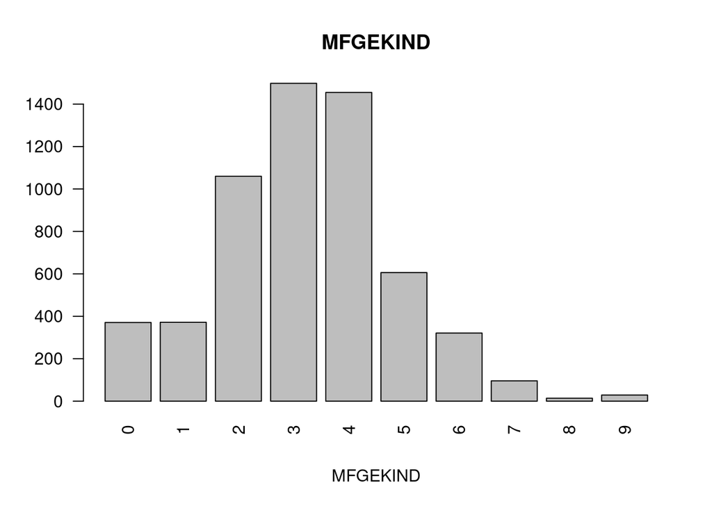

[72 more figures not shown]

```r
par(mfrow = c(1, 1))
cat_vars <- setdiff(names(data), num_vars)
for (var in cat_vars) {
  barplot(table(data[, var]), main = var, xlab = var, las = 2)
}
```